# 第６回 仮説設定

フードデータ分析実習Ⅰ

佐藤 秀保

sato0035@toyo.jp

## 今日の内容

- 前半：先行研究発表（ライフスタイル班）
- 中盤：仮説設定の説明，グループ分け
- 後半：グループごとに仮説を立て，その内容を共有

## 仮説とは？

- 社会調査法Ⅰ第10回スライド5（中島）

「学術研究では，**社会の実態調査や先行研究の調査の結果を踏まえて仮説を設定**する」

- 社会調査法Ⅱ第3回スライド5（竹田）

「学術的な調査では、**何が原因でどのような結果が生じたのか、という因果関係（causality）の説明**をすることが多い」

### [重要]仮説とアンケート質問項目の関係

- 社会調査法Ⅱ第3回スライド6（竹田）

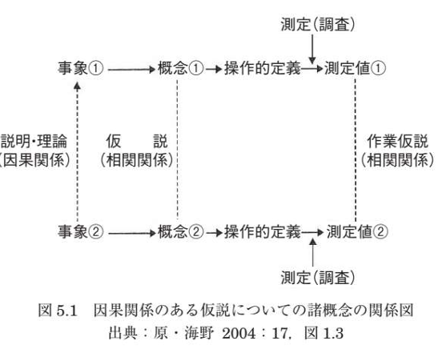

## カテゴリ別で再グルーピング

- 経済/ライフスタイル/食知識・技術/社会・環境
  - （第３回先行研究➁スライド4~7）
- グループピングの理由
  - 個人ワークでは気が付けない点などがあり，ハードルが高い（例：卒論）
  - 予算が個人でwebアンケートをとれるほど潤沢ではない
- 「再」グルーピングの理由
  - 先行研究を眺めてみて，テーマへのイメージが更新された可能性

## やること

1. 社会調査法の資料を参考に仮説を立てる（**事象①，➁**）
2. その仮説が明らかになると，**誰にとって何がどのようによい**のか？
3. 仮説の用語の定義を設定（**概念①，➁**）
4. その仮説を明らかにするには，誰に何を質問すればよいのか？（**操作的定義①，➁**）
- 適宜，先行研究を追加で調べたり既に調べたものを参照
- 理想は以上４点を授業最後に現段階の考えとして発表．
- 3, 4は余裕があれば…

## 課題

- なし

## 次回予告

- 出張のため，対面授業無し
- 当日にACEに内容を掲示